# BL40A2010 Introduction to IoT-Based Systems

## Assignment 1, 04.09.2020

### Author: Kristen Sirel

**(1) Analyze an electric heater as a system following Example 1.1.**

Answer: Electric heater Peculiar operation: Convert electrical energy to heat energy. C1 Conditions of production: Electrical properties of the components (resistance) that converts electrical energy to heat energy. C2 Conditions of reproduction: Maintenance, connection to the electrical grid, change in temperature (temperature-controlled heater). C3 External conditions: User, is there electricity, weather.

**(2) Give one example for each scientific rationalities presented in Section 1.2.1 similar to Example 1.2.**

Answer: Classical: Effectiveness of antibiotics on bacterial. Scientific research and testing. Non-classical: Analysis on the spread of infromation about antibiotic resistant bacterial and its affect on the use on antibiotis. Interventionist: Rise in the number of antibiotic resistant bacteria globally. Doctors start reducing the amount of antibiotics described. Spreading information about overuse of antibiotics. Reduced use of antibiotics on the livestock. Spread of “healthy lifestyle” free of antibiotics.

**(3) Download the air temperature data of one year from [FMI](http://en.ilmatieteenlaitos.fi/download-observations#!/) at the city/region you currently live. Make four (arbitrary) time series plots for one year, one month, one week and one day.**

*Hint:* Code like in the tutorial notebook.

```python
pip install -r requirements.txt
```

```python
#Kristen Sirel
#
import pandas as pd
import matplotlib.pyplot as plt


Temp = pd.read_csv(
"FMI_lpr_2019.csv",dayfirst=True,sep=",",
                          header=0,decimal=b".",index_col=0,
                          parse_dates= [[0, 1, 2, 3]],usecols=[0,1,2,3,5])
Temp.info()
```

```
<class 'pandas.core.frame.DataFrame'>
DatetimeIndex: 8761 entries, 2019-01-01 00:00:00 to 2020-01-01 00:00:00
Data columns (total 1 columns):
 #   Column                  Non-Null Count  Dtype
---  ------                  --------------  -----
 0   Air temperature (degC)  8749 non-null   float64
dtypes: float64(1)
memory usage: 136.9 KB
```

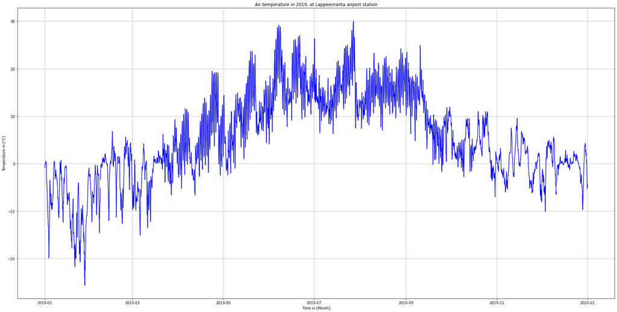

```python
#Year plot
plt.figure(figsize=(30,15))
plt.plot(Temp,color='blue',linestyle='-')
plt.title("Air temperature in 2019, at Lappeenranta airport station")
plt.ylabel("Temperature in [°C]")
plt.xlabel("Time in [Month]")
plt.grid(True)
plt.show()
```

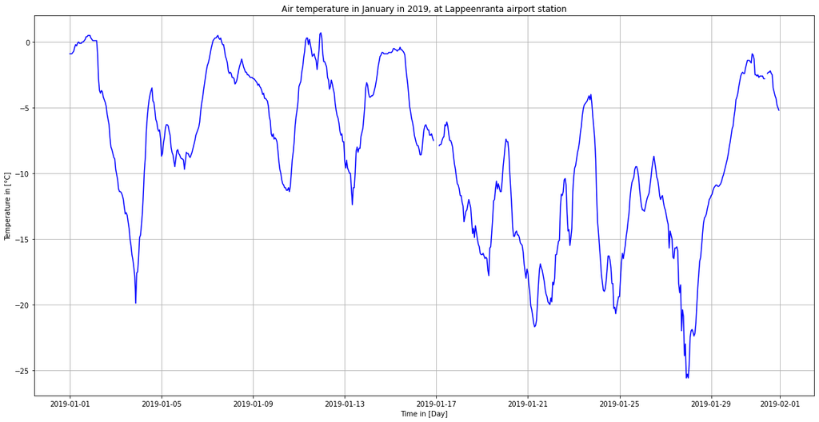

```python
#Month plot
plt.figure(figsize=(20,10))
plt.plot(Temp['2019-1'],color='blue',linestyle='-')
plt.title("Air temperature in January in 2019, at Lappeenranta airport station")
plt.ylabel("Temperature in [°C]")
plt.xlabel("Time in [Day]")
plt.grid(True)
plt.show()
```

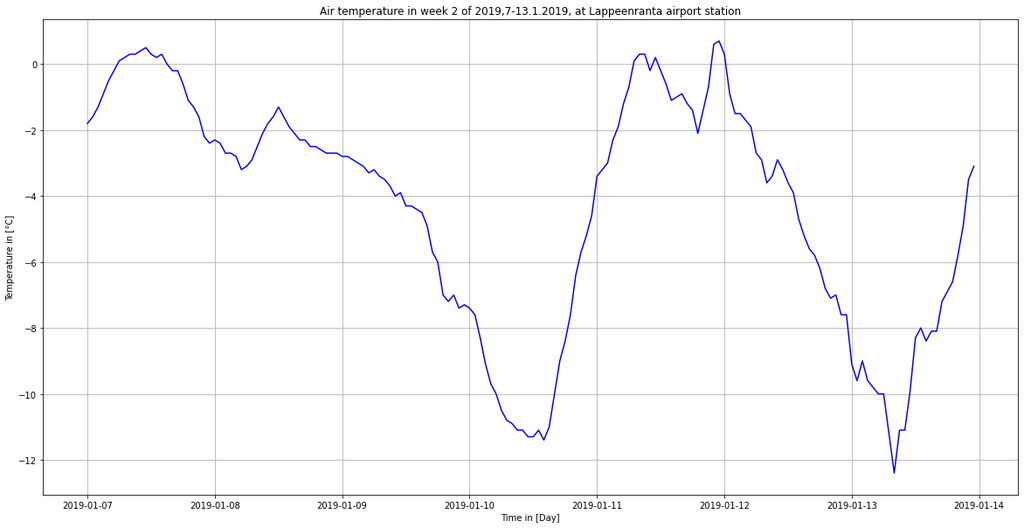

```python
#Week plot
plt.figure(figsize=(20,10))
plt.plot(Temp['2019-1-7':'2019-1-13'],color='blue',linestyle='-')
plt.title("Air temperature in week 2 of 2019,7-13.1.2019, at Lappeenranta airport station")
plt.ylabel("Temperature in [°C]")
plt.xlabel("Time in [Day]")
plt.grid(True)
plt.show()
```

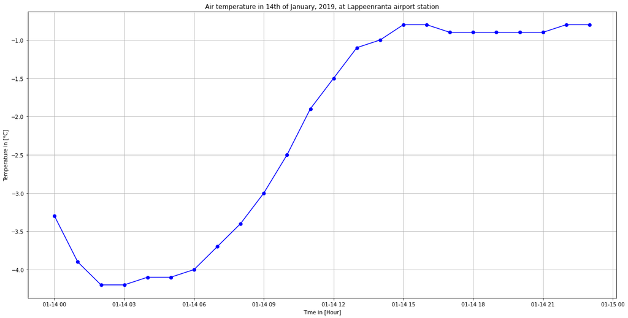

```python
#Day plot
plt.figure(figsize=(20,10))
plt.plot(Temp['2019-1-14'],color='blue', marker='o',linestyle='-')
plt.title("Air temperature in 14th of January, 2019, at Lappeenranta airport station")
plt.ylabel("Temperature in [°C]")
plt.xlabel("Time in [Hour]")
plt.grid(True)
plt.show()

#eof
```

**(4) Consider a house with an electric heater. How the electricity consumption of the heater would be affected by the air temperature? Is there a way to change this?**

Answer: If the heater is temperature controlled, colder air temperature means that the heater must be on more often or longer times compared to warmer air temperature. This makes the heater to consume more electricity. If the air is warmer/close to the desired temperature, time that the heater must be on reduces. At the same time electricity consumption is reduced. By changing control type of the heater, the heater can be changed to output constant heat, so it does not follow air temperature thus consuming constant electrical energy.